# Tester Site

September 01, 2020

Sewage samples are collected weekly from water reclamation facilities that serve Athens Clarke County (WRF A and WRF B). Samples are tested to detect and measure SARS‑CoV‑2, the virus that causes COVID‑19.

We measure the virus by detecting two genes specific to SARS‑CoV‑2, the N1 and N2 nucleocapsid genes, using RT-qPCR. The N1 and N2 gene targets are measured and reported as a concentration, in number of gene copies per liter of wastewater. The theoretical Limit of Detection (LOD) is noted.

We predict that changes in the concentration of SARS‑CoV‑2 in wastewater will reflect the community trends of circulating COVID‑19 infections. The daily number of newly reported COVID‑19 cases in Athens-Clarke County (purple) appear alongside the 10-day moving average of new cases (yellow). Changes in SARS‑CoV‑2 in wastewater may precede changes in reported cases because of lags in clinical testing.

[interactive chart not shown]

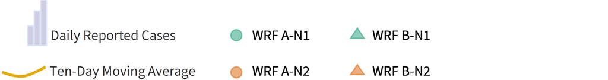

#### Weekly Data Update

*Updated every Thursday*

##### August 18

On August 18, 2020, the concentration of SARS‑CoV‑2 increased to over 100,000 copies per liter for both gene targets. This uptick is somewhat reflected in the daily reported cases for Athens-Clarke county and may indicate further increases in the coming weeks.

Furthermore, this week marks the return of approximately 30,000 undergraduate students to the UGA main campus for the start of the fall semester.

##### Prior to August 18, 2020

Since August 4, 2020 SARS‑CoV‑2 concentration has steadily increased for both the N1 and N2 gene targets. This suggests that sewage concentrations may be a leading indicator for new cases in the community, but more data collection and monitoring of delays in testing reports will be needed to confirm this trend.

#### Research Overview

##### Purpose

Wastewater surveillance is an emerging tool for monitoring disease outbreaks. Coupled with clinical surveillance, wastewater surveillance can be used to estimate the level of viruses circulating in local population.

To better understand the outbreak of the novel Coronavirus disease-19 (COVID‑19) on a local level, we are monitoring wastewater samples from water reclamation facilities in Athens, GA. Wastewater samples are collected weekly and tested to detect the disease-causing virus, SARS‑CoV‑2.

Each sample is a composite of the wastewater received by the water reclamation facility in a single day. By examining these samples, we are capturing a snapshot into the health of the entire community that contributes to the sewershed. This wastewater-based research provides a new approach to epidemiology; sewage surveillance may be used to predict the total burden of disease at a community-scale, without extensive clinical sampling.

We are sharing here some of the preliminary results of our wastewater monitoring program. Our objective is to critically examine the use of SARS‑CoV‑2 wastewater-based epidemiology for the detection and surveillance of SARS‑CoV‑2 in our local community.

We are developing and evaluating our methods in real-time. We will share with you our weekly results and newest developments. This data is intended to complement clinical-based COVID‑19 surveillance data, that will together, inform public health decisions.

To learn more about national surviellence efforts, using wastewater-based epidemiology, please visit the CDC’s [National Wastewater Surveillance System (NWSS).](https://www.cdc.gov/coronavirus/2019-ncov/cases-updates/wastewater-surveillance.html)

##### Methods

Since May 2020, sewage samples have been collected weekly from the water reclamation facilities (WRFs) that serve Athens-Clarke County. Samples are collected from a 24-hour composite of the influent wastewater received by each WRF.

Samples are processed by the Lipp Laboratory at the University of Georgia to detect and measure the abundance of SARS‑CoV‑2 virus in wastewater.

Viral RNA, the genetic material of the SARS‑CoV‑2 virus, is extracted from each sample using the [QIAmp Viral RNA Mini Kit.](https://www.qiagen.com/us/products/diagnostics-and-clinical-research/sample-processing/qiaamp-viral-rna-mini-kit/#orderinginformation)

The viral RNA is then measured using Real-Time RT-PCR Assays, following the [CDC’s test protocol](https://www.cdc.gov/sars/guidance/f-lab/assays.html) for the N1 and N2 SARS‑CoV‑2 nucleocapsid genes.

The N1 and N2 gene targets are measured and reported as a concentration, by the number of gene copies measured per liter of wastewater.

Reported case data for COVID-19 has been collected from [Georgia’s Department of Public Health](https://dph.georgia.gov/covid-19-daily-status-report) and summarized by Mark Ebell, MD, MS [here](https://docs.google.com/spreadsheets/d/e/2PACX-1vS701zSLS_VgpMUVSuGWI89Y05Yev3QCCF-l0nbwtSN1tE-hGlMV1T2Tg0GFVuiVD010szZ1ukr7vnM/pubhtml).

A more detailed explanation of the research methods can be found [here](https://docs.google.com/document/d/1vvRGrvR5iF3P6d40tKPjUpOZBBKGz_OZAr9Z5xJiCKw/edit?usp=sharing).

##### About

This weekly monitoring is conducted in partnership between Athens-Clarke County Utilities, the Lipp Laboratory, and the College of Public Health at the University of Georgia.

**Team**

Dr. Erin Lipp

Megan Lott, PhD Student

William Norfolk, PhD Student

Megan Robertson, PhD Student

For more information about our team and other ongoing research please visit the Lipp Laboratory [website](http://www.lipplab.org/).